# Similarity Judgment Task Analysis: Nouns Abs-Conc

morgan moyer

2025-07-09

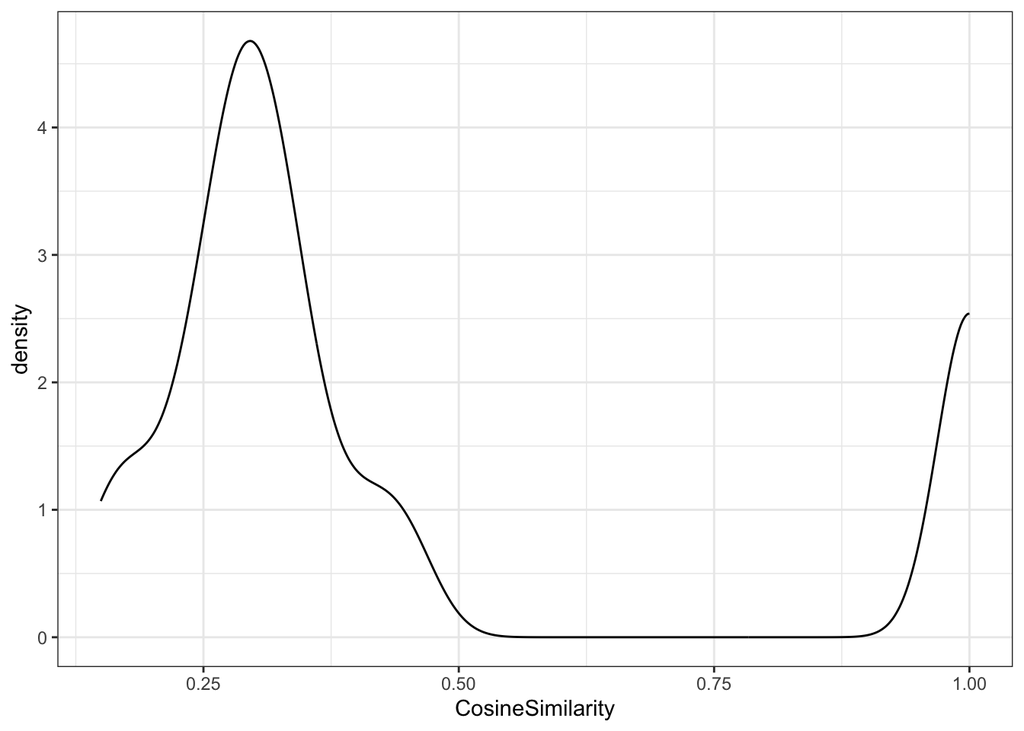

```r
ggplot(d, aes(CosineSimilarity)) +
  geom_density(alpha = .5)
```

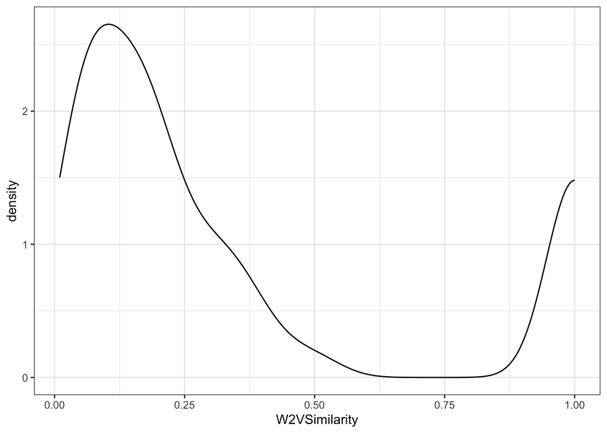

```r
ggplot(d, aes(W2VSimilarity)) +
  geom_density(alpha = .5)
```

```r
names(d)
```

```
## [1] "WordPair"         "X"                "ID.Ibex"          "Response"
## [5] "FeatureMatch"     "Word1"            "Word2"            "W2VSimilarity"
## [9] "CosineSimilarity"
```

```r
dcen <- d %>%
  mutate(WordPair = as.factor(WordPair),
         ID.Ibex = as.factor(ID.Ibex),
         FeatureMatch = as.factor(FeatureMatch),
         cResponse = as.numeric(Response)-mean(as.numeric(Response)))

m <- lmer(cResponse ~ FeatureMatch + (1|WordPair) + (1+FeatureMatch|ID.Ibex), data = dcen)
```

```
## boundary (singular) fit: see help('isSingular')
```

```r
summary(m)
```

```
## Linear mixed model fit by REML. t-tests use Satterthwaite's method [
## lmerModLmerTest]
## Formula: cResponse ~ FeatureMatch + (1 | WordPair) + (1 + FeatureMatch |
##     ID.Ibex)
##    Data: dcen
##
## REML criterion at convergence: 4309.3
##
## Scaled residuals:
##     Min      1Q  Median      3Q     Max
## -3.9487 -0.3025 -0.0007  0.1743  5.3123
##
## Random effects:
##  Groups   Name                            Variance Std.Dev. Corr
##  WordPair (Intercept)                     257.26   16.039
##  ID.Ibex  (Intercept)                      32.57    5.707
##           FeatureMatchMaxMatch            187.52   13.694   -0.69
##           FeatureMatchMaxMismatch          15.11    3.887   -0.99  0.59
##           FeatureMatchSelfPair             32.61    5.711   -1.00  0.69  0.99
##           FeatureMatchValenceMatchingOnly 109.41   10.460   -0.34  0.92  0.22
##  Residual                                 255.44   15.982
##
##
##
##
##
##
##   0.34
##
## Number of obs: 500, groups:  WordPair, 50; ID.Ibex, 10
##
## Fixed effects:
##                                 Estimate Std. Error      df t value Pr(>|t|)
## (Intercept)                      -25.108      5.616  46.698  -4.471 4.95e-05
## FeatureMatchMaxMatch              26.950      8.678  42.270   3.105  0.00339
## FeatureMatchMaxMismatch           -4.290      7.620  45.956  -0.563  0.57620
## FeatureMatchSelfPair              91.460      7.734  46.785  11.825 1.17e-15
## FeatureMatchValenceMatchingOnly   11.420      8.216  46.479   1.390  0.17116
##
## (Intercept)                     ***
## FeatureMatchMaxMatch            **
## FeatureMatchMaxMismatch
## FeatureMatchSelfPair            ***
## FeatureMatchValenceMatchingOnly
## ---
## Signif. codes:  0 '***' 0.001 '**' 0.01 '*' 0.05 '.' 0.1 ' ' 1
##
## Correlation of Fixed Effects:
##             (Intr) FtrMtchMxMt FtrMtchMxMs FtrMSP
## FtrMtchMxMt -0.690
## FtrMtchMxMs -0.712  0.475
## FtrMtchSlfP -0.726  0.501       0.517
## FtrMtchVlMO -0.657  0.581       0.466       0.477
## optimizer (nloptwrap) convergence code: 0 (OK)
## boundary (singular) fit: see help('isSingular')
```

### Plot fixed effect estimates with confidence intervals

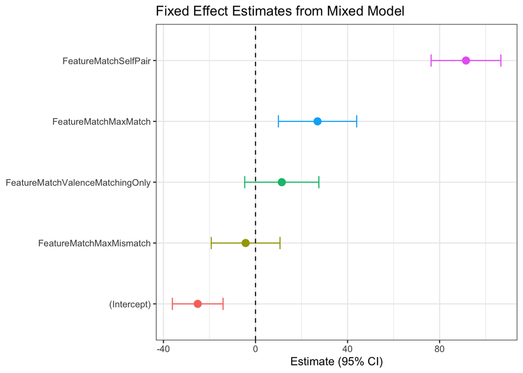

```r
# Tidy the model output
coefs <- tidy(m, effects = "fixed")
# Reorder by effect size for prettier plotting
coefs$term <- factor(coefs$term, levels = coefs$term[order(coefs$estimate)])

# Then replot
ggplot(coefs, aes(x = estimate, y = term, color = term)) +
  geom_point(size = 3) +
  geom_errorbarh(aes(xmin = estimate - 1.96 * std.error,
                     xmax = estimate + 1.96 * std.error), height = 0.2) +
  geom_vline(xintercept = 0, linetype = "dashed") +
  # theme_minimal(base_size = 14) +
  labs(title = "Fixed Effect Estimates from Mixed Model",
       x = "Estimate (95% CI)", y = NULL) +
  theme(legend.position="none")
```

### Plot predicted values vs. predictors

You can create a dataset of predicted values from your model and plot how the response changes with predictors:

```r
newdata <- expand.grid(
  FeatureMatch = levels(dcen$FeatureMatch))
```

2. Get predicted values and standard errors from the model

```r
pred <- predict(m, newdata = newdata, re.form = NA, se.fit = TRUE)
```

3. Add predictions and confidence intervals to newdata

```r
newdata$fit <- pred$fit
newdata$se <- pred$se.fit
newdata <- newdata %>%
  mutate(
    conf.low = fit - 1.96 * se,
    conf.high = fit + 1.96 * se
  )
```

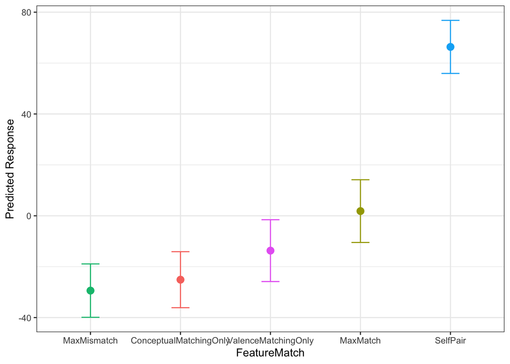

```r
ggplot(newdata, aes(x = reorder(FeatureMatch,fit), y = fit, color = FeatureMatch, fill = FeatureMatch)) +
  geom_point(size = 3) +
  geom_errorbar(aes(ymin = conf.low, ymax = conf.high), width = 0.2) +
  # theme_minimal() +
  labs(x = "FeatureMatch", y = "Predicted Response", color = "FeatureMatch", fill = "FeatureMatch") +
  theme(legend.position="none")
```

## You can visualize individual random effect estimates:

What you get from the plot: A visual summary of the variability in random effects across levels of your grouping factors.

Helps you identify:

Which groups (subjects/items) deviate strongly from the average effect,

How precise these deviations are,

Whether there are outliers or patterns in random effects.

Example interpretation: If a subject’s random intercept dot is far from zero with narrow error bars, that subject consistently differs from the average intercept with high certainty.

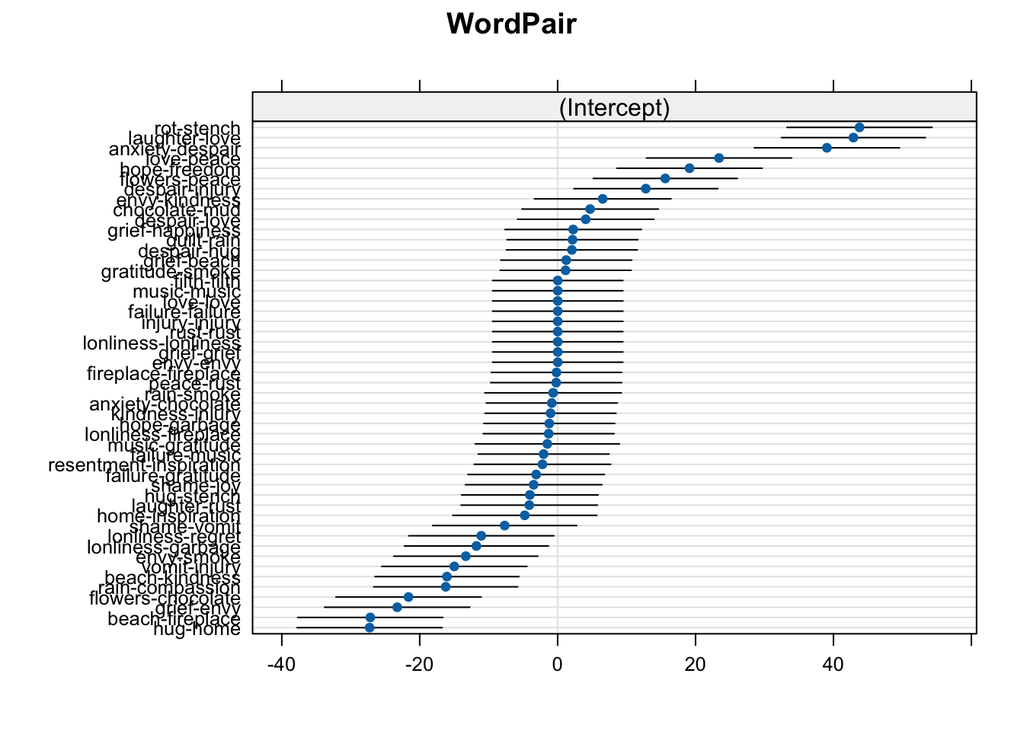

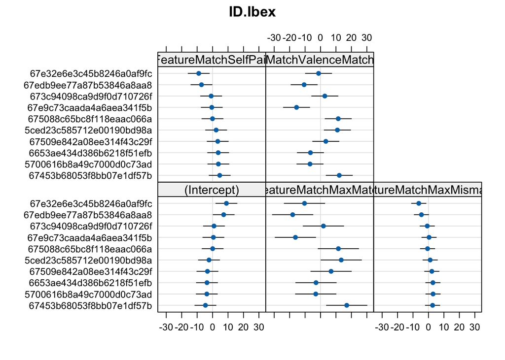

```r
dotplot(ranef(m, condVar=TRUE))
```

## Check model diagnostics

For residuals, fitted vs residuals, etc.:

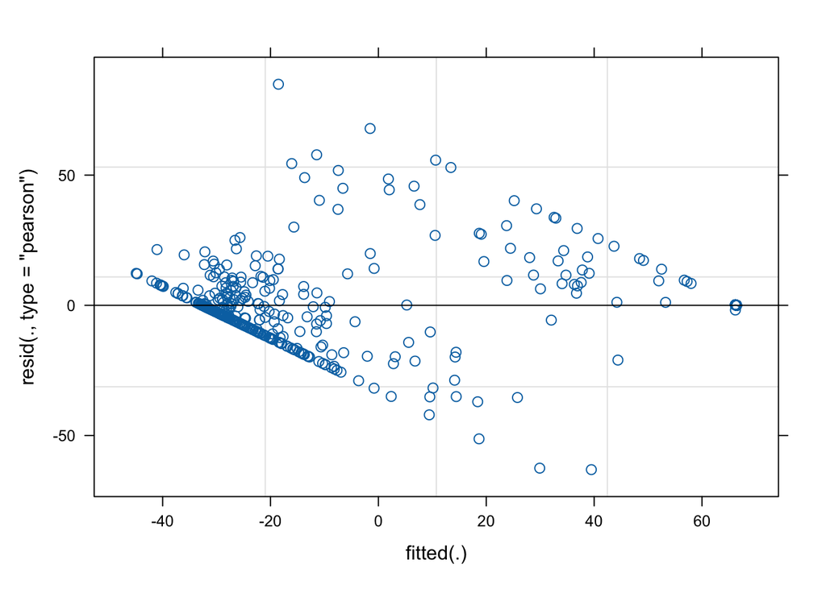

```r
plot(m)
```

# Does Similarity predict or interact with FeatureMatch?

## Cosine Similarity from Transformer Models

- No.

```r
m.full <- lmer(cResponse ~ FeatureMatch*CosineSimilarity + (1|WordPair) + (1|ID.Ibex), data = dcen)
```

```
## fixed-effect model matrix is rank deficient so dropping 1 column / coefficient
```

```r
summary(m.full)
```

```
## Linear mixed model fit by REML. t-tests use Satterthwaite's method [
## lmerModLmerTest]
## Formula: cResponse ~ FeatureMatch * CosineSimilarity + (1 | WordPair) +
##     (1 | ID.Ibex)
##    Data: dcen
##
## REML criterion at convergence: 4301.5
##
## Scaled residuals:
##     Min      1Q  Median      3Q     Max
## -4.2825 -0.3826 -0.1197  0.2386  4.7572
##
## Random effects:
##  Groups   Name        Variance Std.Dev.
##  WordPair (Intercept) 239.55   15.48
##  ID.Ibex  (Intercept)  14.14    3.76
##  Residual             291.34   17.07
## Number of obs: 500, groups:  WordPair, 50; ID.Ibex, 10
##
## Fixed effects:
##                                                  Estimate Std. Error      df
## (Intercept)                                       -30.406     26.673  41.162
## FeatureMatchMaxMatch                                3.355     35.179  41.000
## FeatureMatchMaxMismatch                            -1.231     39.421  41.000
## FeatureMatchSelfPair                               80.024     56.889  41.000
## FeatureMatchValenceMatchingOnly                   -19.531     31.938  41.000
## CosineSimilarity                                   16.735     82.551  41.000
## FeatureMatchMaxMatch:CosineSimilarity              71.389    107.108  41.000
## FeatureMatchMaxMismatch:CosineSimilarity           -8.273    135.959  41.000
## FeatureMatchValenceMatchingOnly:CosineSimilarity  115.223    102.794  41.000
##                                                  t value Pr(>|t|)
## (Intercept)                                       -1.140    0.261
## FeatureMatchMaxMatch                               0.095    0.924
## FeatureMatchMaxMismatch                           -0.031    0.975
## FeatureMatchSelfPair                               1.407    0.167
## FeatureMatchValenceMatchingOnly                   -0.612    0.544
## CosineSimilarity                                   0.203    0.840
## FeatureMatchMaxMatch:CosineSimilarity              0.667    0.509
## FeatureMatchMaxMismatch:CosineSimilarity          -0.061    0.952
## FeatureMatchValenceMatchingOnly:CosineSimilarity   1.121    0.269
##
## Correlation of Fixed Effects:
##                (Intr) FtrMtchMxMt FtrMtchMxMs FtrMSP FtMVMO CsnSml
## FtrMtchMxMt    -0.757
## FtrMtchMxMs    -0.675  0.512
## FtrMtchSlfP     0.954 -0.723      -0.646
## FtrMtchVlMO    -0.833  0.632       0.564      -0.797
## CosinSmlrty    -0.980  0.743       0.663      -0.992  0.818
## FtrMtchMxMt:CS  0.755 -0.978      -0.511       0.764 -0.631 -0.771
## FtrMtchMxMs:CS  0.595 -0.451      -0.979       0.602 -0.497 -0.607
## FtrMtVMO:CS     0.787 -0.597      -0.532       0.796 -0.971 -0.803
##                FtrMtchMxMt:CS FtrMtchMxMs:CS
## FtrMtchMxMt
## FtrMtchMxMs
## FtrMtchSlfP
## FtrMtchVlMO
## CosinSmlrty
## FtrMtchMxMt:CS
## FtrMtchMxMs:CS  0.468
## FtrMtVMO:CS     0.619          0.488
## fit warnings:
## fixed-effect model matrix is rank deficient so dropping 1 column / coefficient
```

## Does adding Cosine Similarity explain any more variance in the data?

- no

```r
m.s <- lmer(cResponse ~ FeatureMatch + (1|WordPair) + (1|ID.Ibex), data = dcen)

anova(m.s, m.full, REML=FALSE)
```

```
## refitting model(s) with ML (instead of REML)
```

```
## Data: dcen
## Models:
## m.s: cResponse ~ FeatureMatch + (1 | WordPair) + (1 | ID.Ibex)
## m.full: cResponse ~ FeatureMatch * CosineSimilarity + (1 | WordPair) + (1 | ID.Ibex)
##        npar    AIC    BIC  logLik deviance  Chisq Df Pr(>Chisq)
## m.s       8 4391.9 4425.6 -2187.9   4375.9
## m.full   12 4392.7 4443.3 -2184.3   4368.7 7.1739  4      0.127
```

### Plot fixed effect estimates with confidence intervals

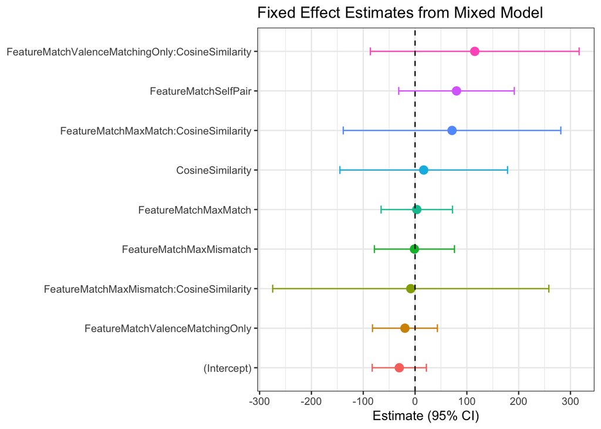

```r
# Tidy the model output
coefs <- tidy(m.full, effects = "fixed")

# Reorder by effect size for prettier plotting
coefs$term <- factor(coefs$term, levels = coefs$term[order(coefs$estimate)])

# Then replot
ggplot(coefs, aes(x = estimate, y = term, color = term)) +
  geom_point(size = 3) +
  geom_errorbarh(aes(xmin = estimate - 1.96 * std.error,
                     xmax = estimate + 1.96 * std.error), height = 0.2) +
  geom_vline(xintercept = 0, linetype = "dashed") +
  # theme_minimal(base_size = 14) +
  labs(title = "Fixed Effect Estimates from Mixed Model",
       x = "Estimate (95% CI)", y = NULL) +
  theme(legend.position="none")
```

## Word-2-Vec Similarity

```r
m.full <- lmer(cResponse ~ FeatureMatch*W2VSimilarity + (1|WordPair) + (1|ID.Ibex), data = dcen)
```

```
## fixed-effect model matrix is rank deficient so dropping 1 column / coefficient
```

```r
summary(m.full)
```

```
## Linear mixed model fit by REML. t-tests use Satterthwaite's method [
## lmerModLmerTest]
## Formula: cResponse ~ FeatureMatch * W2VSimilarity + (1 | WordPair) + (1 |
##     ID.Ibex)
##    Data: dcen
##
## REML criterion at convergence: 4294.8
##
## Scaled residuals:
##     Min      1Q  Median      3Q     Max
## -4.2852 -0.3937 -0.1169  0.2388  4.7811
##
## Random effects:
##  Groups   Name        Variance Std.Dev.
##  WordPair (Intercept) 186.64   13.661
##  ID.Ibex  (Intercept)  14.17    3.764
##  Residual             291.33   17.068
## Number of obs: 500, groups:  WordPair, 50; ID.Ibex, 10
##
## Fixed effects:
##                                               Estimate Std. Error      df
## (Intercept)                                    -27.624      9.394  42.245
## FeatureMatchMaxMatch                           -10.205     15.210  40.998
## FeatureMatchMaxMismatch                         -2.298     12.076  40.998
## FeatureMatchSelfPair                            82.230     30.355  40.998
## FeatureMatchValenceMatchingOnly                 -3.707     13.034  40.998
## W2VSimilarity                                   11.746     37.714  40.998
## FeatureMatchMaxMatch:W2VSimilarity             144.774     57.758  40.998
## FeatureMatchMaxMismatch:W2VSimilarity           -4.886     88.599  40.998
## FeatureMatchValenceMatchingOnly:W2VSimilarity  116.143     68.207  40.998
##                                               t value Pr(>|t|)
## (Intercept)                                    -2.941   0.0053 **
## FeatureMatchMaxMatch                           -0.671   0.5060
## FeatureMatchMaxMismatch                        -0.190   0.8500
## FeatureMatchSelfPair                            2.709   0.0098 **
## FeatureMatchValenceMatchingOnly                -0.284   0.7775
## W2VSimilarity                                   0.311   0.7570
## FeatureMatchMaxMatch:W2VSimilarity              2.507   0.0162 *
## FeatureMatchMaxMismatch:W2VSimilarity          -0.055   0.9563
## FeatureMatchValenceMatchingOnly:W2VSimilarity   1.703   0.0962 .
```

[output cut: 11 more lines]

```
## FtrMtchMxMs:W2VS  0.366 -0.226      -0.743       0.416 -0.264 -0.426
## FtMVMO:W2VS       0.475 -0.294      -0.370       0.540 -0.844 -0.553
##                  FtrMtchMxMt:W2VS FtrMtchMxMs:W2VS
## FtrMtchMxMt
## FtrMtchMxMs
## FtrMtchSlfP
## FtrMtchVlMO
## W2VSimilrty
## FtrMtchMxMt:W2VS
## FtrMtchMxMs:W2VS  0.278
## FtMVMO:W2VS       0.361            0.235
## fit warnings:
## fixed-effect model matrix is rank deficient so dropping 1 column / coefficient
## optimizer (nloptwrap) convergence code: 0 (OK)
## Model failed to converge with max|grad| = 0.00436507 (tol = 0.002, component 1)
```

```r
m.s <- lmer(cResponse ~ FeatureMatch + (1|WordPair) + (1|ID.Ibex), data = dcen)
```

## Does adding Word-2-Vec Similarity explain any more variance in the data?

- Yes

```r
anova(m.s, m.full, REML=FALSE)
```

```
## refitting model(s) with ML (instead of REML)
```

```
## Data: dcen
## Models:
## m.s: cResponse ~ FeatureMatch + (1 | WordPair) + (1 | ID.Ibex)
## m.full: cResponse ~ FeatureMatch * W2VSimilarity + (1 | WordPair) + (1 | ID.Ibex)
##        npar    AIC    BIC  logLik deviance  Chisq Df Pr(>Chisq)
## m.s       8 4391.9 4425.6 -2187.9   4375.9
## m.full   12 4381.8 4432.4 -2178.9   4357.8 18.086  4   0.001187 **
## ---
## Signif. codes:  0 '***' 0.001 '**' 0.01 '*' 0.05 '.' 0.1 ' ' 1
```

### Plot fixed effect estimates with confidence intervals

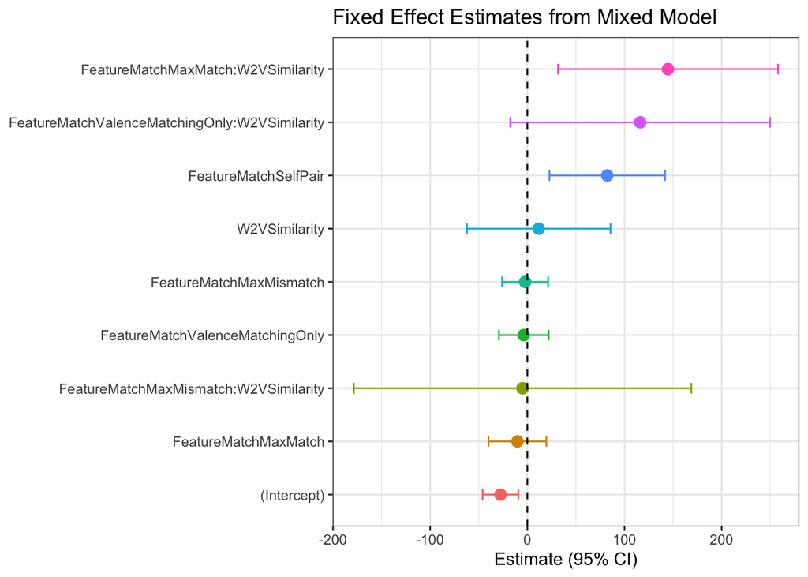

```r
# Tidy the model output
coefs <- tidy(m.full, effects = "fixed")

# Reorder by effect size for prettier plotting
coefs$term <- factor(coefs$term, levels = coefs$term[order(coefs$estimate)])

# Then replot
ggplot(coefs, aes(x = estimate, y = term, color = term)) +
  geom_point(size = 3) +
  geom_errorbarh(aes(xmin = estimate - 1.96 * std.error,
                     xmax = estimate + 1.96 * std.error), height = 0.2) +
  geom_vline(xintercept = 0, linetype = "dashed") +
  # theme_minimal(base_size = 14) +
  labs(title = "Fixed Effect Estimates from Mixed Model",
       x = "Estimate (95% CI)", y = NULL) +
  theme(legend.position="none")
```

### Plot predicted values vs. predictors

You can create a dataset of predicted values from your model and plot how the response changes with predictors:

1. Create a new dataset with combinations of predictors
- Generates all combinations of levels of FeatureMatch (a factor) and a sequence of W2VSimilarity values from -0.01 to 1 (100 points).
- Because: You want to predict your response across a continuous range of W2VSimilarity for each FeatureMatch group.

```r
newdata <- expand.grid(
  FeatureMatch = levels(dcen$FeatureMatch),
  W2VSimilarity = seq(-0.01, 1, length.out = 100)
)
```

2. Get predicted values and standard errors from the model

```r
pred <- predict(m.full, newdata = newdata, re.form = NA, se.fit = TRUE)
```

3. Add predictions and confidence intervals to newdata

```r
newdata$fit <- pred$fit
newdata$se <- pred$se.fit
newdata <- newdata %>%
  mutate(
    conf.low = fit - 1.96 * se,
    conf.high = fit + 1.96 * se
  )
```

4. Plot predicted lines with ribbons for confidence intervals

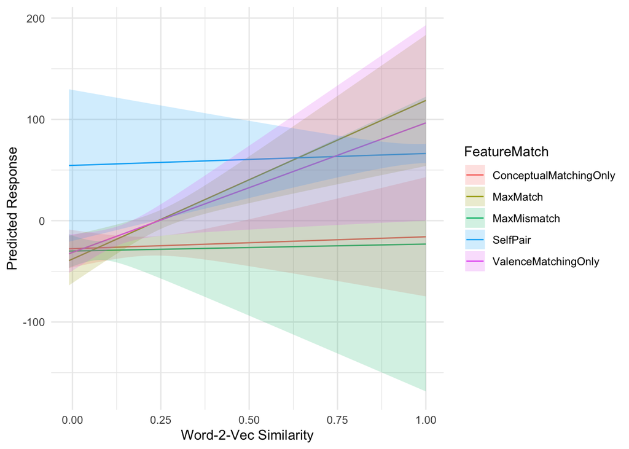

```r
ggplot(newdata, aes(x = W2VSimilarity, y = fit, color = FeatureMatch, fill = FeatureMatch)) +
  geom_line() +
  geom_ribbon(aes(ymin = conf.low, ymax = conf.high), alpha = 0.2, color = NA) +
  theme_minimal() +
  labs(x = "Word-2-Vec Similarity", y = "Predicted Response", color = "FeatureMatch", fill = "FeatureMatch")
```

### Visualize individual random effect estimates:

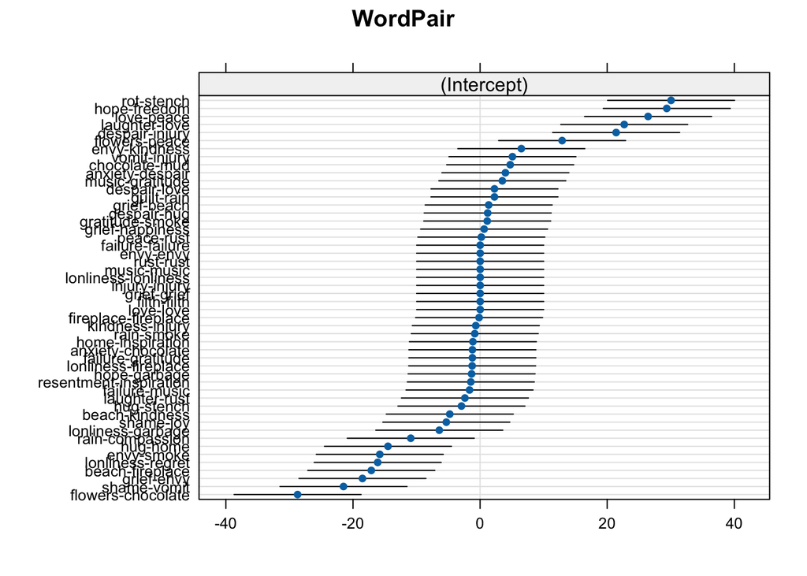

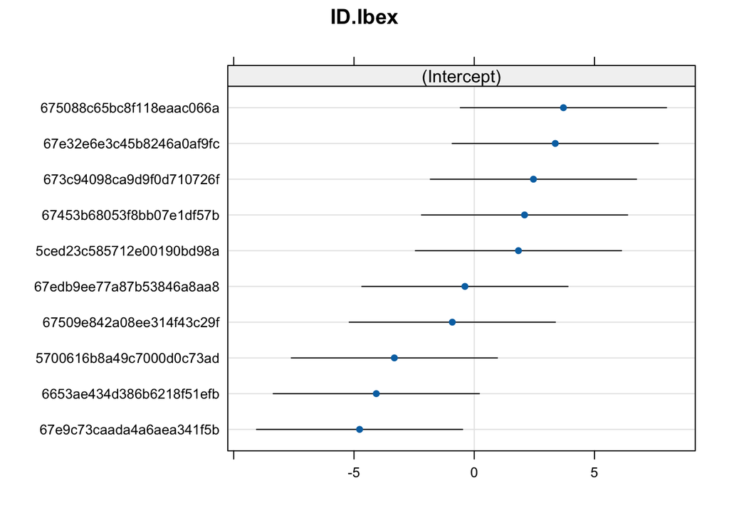

```r
dotplot(ranef(m.full, condVar=TRUE))
```

### Check model diagnostics

For residuals, fitted vs residuals, etc.:

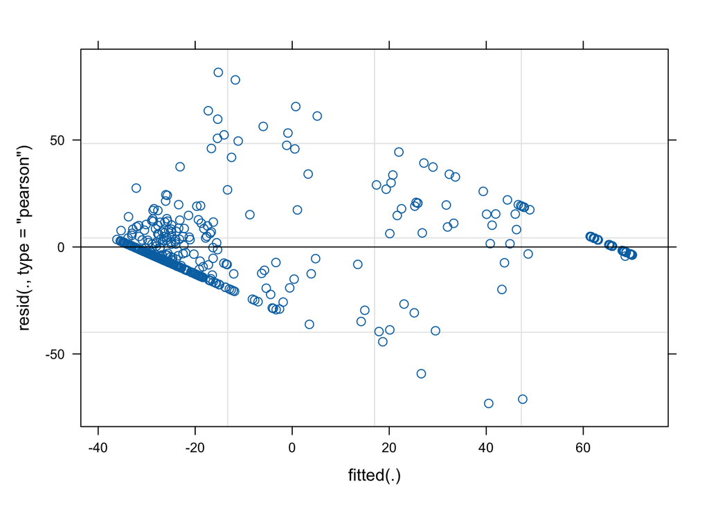

```r
plot(m.full)
```

# Similarity Alone

```r
m <- lmer(cResponse ~ W2VSimilarity + (1|WordPair) + (1|ID.Ibex), data = dcen)
summary(m)
```

```
## Linear mixed model fit by REML. t-tests use Satterthwaite's method [
## lmerModLmerTest]
## Formula: cResponse ~ W2VSimilarity + (1 | WordPair) + (1 | ID.Ibex)
##    Data: dcen
##
## REML criterion at convergence: 4370.8
##
## Scaled residuals:
##     Min      1Q  Median      3Q     Max
## -4.2673 -0.4191 -0.1077  0.2414  4.7038
##
## Random effects:
##  Groups   Name        Variance Std.Dev.
##  WordPair (Intercept) 260.66   16.145
##  ID.Ibex  (Intercept)  14.14    3.761
##  Residual             291.34   17.069
## Number of obs: 500, groups:  WordPair, 50; ID.Ibex, 10
##
## Fixed effects:
##               Estimate Std. Error      df t value Pr(>|t|)
## (Intercept)    -33.394      3.553  52.050  -9.399 8.38e-13 ***
## W2VSimilarity   99.275      6.917  48.001  14.352  < 2e-16 ***
## ---
## Signif. codes:  0 '***' 0.001 '**' 0.01 '*' 0.05 '.' 0.1 ' ' 1
##
## Correlation of Fixed Effects:
##             (Intr)
## W2VSimilrty -0.655
```

```r
m <- lmer(cResponse ~ CosineSimilarity + (1|WordPair) + (1|ID.Ibex), data = dcen)
summary(m)
```

```
## Linear mixed model fit by REML. t-tests use Satterthwaite's method [
## lmerModLmerTest]
## Formula: cResponse ~ CosineSimilarity + (1 | WordPair) + (1 | ID.Ibex)
##    Data: dcen
##
## REML criterion at convergence: 4377.9
##
## Scaled residuals:
##     Min      1Q  Median      3Q     Max
## -4.2733 -0.3970 -0.1166  0.2407  4.6454
##
## Random effects:
##  Groups   Name        Variance Std.Dev.
##  WordPair (Intercept) 309.03   17.58
##  ID.Ibex  (Intercept)  14.14    3.76
##  Residual             291.34   17.07
## Number of obs: 500, groups:  WordPair, 50; ID.Ibex, 10
##
## Fixed effects:
##                  Estimate Std. Error      df t value Pr(>|t|)
## (Intercept)       -51.132      4.857  52.061  -10.53 1.68e-14 ***
## CosineSimilarity  117.071      8.988  48.000   13.03  < 2e-16 ***
## ---
## Signif. codes:  0 '***' 0.001 '**' 0.01 '*' 0.05 '.' 0.1 ' ' 1
##
## Correlation of Fixed Effects:
##             (Intr)
## CosinSmlrty -0.808
```